# VH Study 4v2: Heterogeneous Cluster Information

Author

Michael Hallquist and Zach Vig

Published

August 26, 2026

# 1 Executive summary

Study 4v2 asks whether methods that use row-specific Stage-1 uncertainty retain their advantage when clusters differ sharply in measurement information. The amended design uses the same shape-preserving posterior-reliability calibrator as Studies 1v2–3v2, then varies the distribution of cluster sizes while holding the target mean reliability interpretable.

All 111 planned conditions are complete: 108 factorial cells plus three slope-information controls. Each condition contains 1,000 replications and all 11 methods. This report has a strict v2 guard and cannot silently read the legacy Study 4 cache.

The main results are:

1. Row-specific stabilized Fuller is nearly centered (mean bias 0.002) with 95.1% non-null conditional coverage and complete interval eligibility.
2. Fuller is mildly conservative under the null: average Type I error is 3.5%. Lai 2S-PA is similarly conservative, while MSEM is approximately nominal.
3. Averaging measurement information is not harmless. Average-measurement Fuller has more negative bias and lower coverage than row-specific Fuller, especially as information becomes heterogeneous. Its success-and-cover probability is also reduced by incomplete eligibility.
4. Lai’s averaging comparison is more nuanced. 2S-PAA reduces the positive bias of row-specific 2S-PA on average, but has lower coverage. Both have incomplete fit eligibility, so conditional coverage overstates operational success.
5. The severe slope-information control behaves more like homogeneous measurement than the ordinary severe profile. Unequal cluster counts alone are therefore not the operative mechanism; heterogeneity in slope information and the full posterior-error matrices matters.

# 2 Scientific motivation

Real repeated-measures data rarely give every person the same information. Participants miss assessments, enter at different times, or contribute measurements at time points with different leverage for estimating a slope. Two people can therefore have the same kind of latent slope but very different posterior uncertainty. Study 4 asks whether Stage 2 must retain that person-specific uncertainty or whether replacing it by one average matrix is adequate.

The structural model is the Study 2 predictor model,

$$y_{it}=\gamma_0+\gamma_1x_{it}+u_{0i}+u_{1i}x_{it}+e_{it},
\qquad
z_i=\beta_0+\beta_{0u}u_{0i}+\beta u_{1i}+\varepsilon_i,$$

but the cluster-specific observation schedules vary. This isolates a practical question that a homogeneous design cannot answer: whether the *distribution* of slope information matters even when the mean reliability target is held fixed.

# 3 Design and v2-only completion contract

The factorial portion crosses three posterior-reliability targets, two intercept–slope correlations, three information profiles, three cluster counts, and null versus non-null structural effects. The three additional control conditions use severely unequal cluster sizes but match slope information.

The method set is designed around the row-specific-versus-average contrast:

- **Oracle**, **naive dual-BLUP OLS**, **unshrunk-score OLS**, and **MSEM** have the same benchmark or negative-control roles as in Study 2.
- **Fuller (row-specific)** carries each cluster’s Stage-1 error matrix into the correction; **Fuller (average measurement)** replaces those matrices by one average. The latter is a deliberate approximation, not the proposed method.
- **Lai 2S-PA (row-specific)** and **Lai 2S-PAA (average)** provide the analogous contrast in the latent path-analysis framework.
- Fuller book-equation and alpha-stepdown variants remain variance-tail and algebra sensitivity checks.

| item | value |
| --- | --- |
| Expected conditions | 111 |
| Observed conditions | 111 |
| Factorial conditions | 108 |
| Slope-information controls | 3 |
| Methods per condition | 11 |
| Replications per condition | 1000 |
| Study version | v2 |
| Calibration version | shape_preserving_v2 |
| Covariance shape fixed | TRUE |
| Slope/intercept variance ratio | 1 |
| Summary artifacts read | 111 |
| Oldest summary artifact (local time) | 2026-08-24 20:43:33 |
| Newest summary artifact (local time) | 2026-08-25 11:34:56 |

The report reads these exact condition summaries directly, with no legacy or consolidated-cache fallback.

# 4 Common terminology and performance metrics

The four v2 reports use the same vocabulary and denominator rules. A **simulation condition** (or *cell*) is one combination of design factors, such as the number of clusters, observations per cluster, reliability, correlation, and true structural effect. Unless a pooled count is explicitly reported, summaries give every condition equal weight. This prevents a method with more eligible fits in easy conditions from implicitly receiving more weight. If an entire condition has no eligible interval, its conditional coverage and SE quantities are undefined and are omitted from the cross-condition average; eligibility and success-and-cover still retain that condition’s failures.

## 4.1 Measurement and model terminology

- The **data-generating model (DGM)** is the population mechanism used to create a simulated data set. An **estimand** is the population quantity the analysis is intended to recover; here it is the standardized structural coefficient, not merely a regression coefficient among estimated scores.
- A **cluster** is the Level-2 unit (for example, a person) observed repeatedly at Level 1. A **random intercept** is that unit’s deviation in level; a **random slope** is its deviation in the within-unit association with the Level-1 predictor. The structural regression asks whether these latent between-unit differences predict, or are predicted by, another variable.
- A **BLUP** (best linear unbiased predictor), also called an empirical Bayes score, is the mixed model’s conditional prediction of a cluster’s random effect. BLUPs deliberately shrink noisy cluster estimates toward the population mean. That improves prediction of an individual random effect but generally makes a subsequent regression on the BLUP target a shrunken quantity rather than the intended latent-effect relation.
- An **unshrunk score** reverses the fitted BLUP shrinkage map to recover a score on the latent random-effect scale. Unshrinking repairs the shrinkage target, but the recovered score remains noisy. If it is used as a predictor, Stage 2 must still account for its measurement-error covariance.
- **Fuller (stabilized)** is the proposed two-stage moment correction. It uses unshrunk scores and their estimated Stage-1 error-covariance matrices, then stabilizes the sampling-variance calculation. The book-equation and alpha-stepdown versions are algebra and tail-sensitivity checks. References to the variance **bread** mean the inverse sensitivity/information component of a sandwich variance estimator, not a second point-estimation correction.
- **Lai 2S-PA** is Lai’s two-stage path-analysis approach: Stage-1 scores and their uncertainty enter a latent-variable path model. **2S-PAA** replaces row-specific uncertainty by an average matrix. **MSEM** is a one-stage multilevel structural equation model. An **oracle** uses the simulated true random effects and supplies a finite-sample benchmark that an applied method cannot attain in real data.
- A **negative control** is a deliberately inadequate estimator whose expected failure has diagnostic value. For example, naive BLUP regression should show shrinkage attenuation. If it did not, the simulation or reporting pipeline would itself require scrutiny.

**Marginal posterior slope reliability** is the primary information target:

$$R = 1 - \frac{E\{V_{i,\mathrm{post}}[\mathrm{slope},\mathrm{slope}]\}}
{G[\mathrm{slope},\mathrm{slope}]}.$$

Here, $G$ is the population random intercept–slope covariance matrix and $V_{i,\mathrm{post}}$ is the remaining posterior uncertainty for cluster $i$ under its observation schedule. Thus, $R=.80$ means that the repeated measurements remove about 80% of the slope’s prior or marginal uncertainty, not that 80% of single observations are signal. **Residualized-slope reliability**, $R_\eta$, applies the same idea to the component of the slope left after its linear association with the random intercept is removed. It can differ from marginal reliability when intercepts and slopes correlate.

An **ICC** is a variance share for an observation under a specified predictor value or contrast. It is not interchangeable with posterior reliability: posterior reliability also uses the number and placement of repeated observations. The v2 **shape-preserving calibration** varies Level-1 residual noise to attain the requested $R$ while holding the slope/intercept variance ratio and intercept–slope correlation fixed. Reliability contrasts therefore do not silently become contrasts in latent covariance geometry.

The **condition number** summarizes how unequal the principal variances of a covariance matrix are: one is perfectly balanced, while a very large value signals near-singularity and numerical sensitivity. A covariance estimate is **positive definite** when it represents strictly positive variation in every linear combination of its latent variables. Zero/negative variances or a nonpositive eigenvalue place a fitted covariance on or beyond an inadmissible boundary.

## 4.2 What each performance quantity answers

| Quantity | Definition and interpretation |
| --- | --- |
| Bias | The mean eligible estimate minus the true coefficient. Bias diagnoses centering; positive and negative values indicate over- and underestimation. Absolute bias ignores direction. |
| Relative bias | Bias divided by the nonzero true coefficient. It puts attenuation on a comparable percentage scale; it is undefined at the null. |
| RMSE | Root mean squared error, combining squared bias and sampling variability of point estimates. It is especially useful for individual-score recovery, where a shrunken predictor can have low RMSE despite… |
| Empirical sampling SD | The standard deviation of the estimates across repeated simulated samples. It is the Monte Carlo approximation to how much the estimator actually varies from sample to sample. |
| Model SE | The standard error reported by the method within one simulated sample. It is the method’s own estimate of repeated-sample uncertainty. |
| Conditional coverage | Among replications that return an eligible interval, the proportion of nominal 95% intervals containing the truth. It answers a conditional calibration question and excludes failed or inadmissible int… |
| Interval eligibility | The proportion of all attempted replications that return an admissible point estimate, a finite positive SE, and ordered confidence limits under the prespecified method-specific checks. |
| Success-and-cover | The joint proportion of all attempted replications that both return an eligible interval and cover the truth. Within a cell it equals interval eligibility multiplied by conditional coverage. It is an … |
| Type I error | In null cells, the proportion of eligible intervals that exclude zero. With the two-sided interval-inversion rule it equals one minus conditional coverage. Operational Type I error instead divides suc… |
| Power | In non-null cells, the proportion of eligible intervals that exclude zero. Operational power uses all attempted replications as the denominator. |
| Monte Carlo SE | Simulation uncertainty in an estimated bias or rate. It describes precision of the simulation summary, not uncertainty in a fitted empirical-data coefficient. |

A **Monte Carlo confidence interval** applies the Monte Carlo SE (or a binomial interval for a rate) to a simulation summary. It asks how precisely the simulation has estimated performance. A 95% **Wald confidence interval** in an individual replication is instead the fitted coefficient plus or minus a normal critical value times its model SE; those are the intervals whose coverage is being evaluated.

The standard-error calibration plots require one additional distinction. For each condition $c$, the report computes

$$Q_c =
\frac{\text{mean reported SE among interval-eligible replications}}
{\text{empirical SD of estimates in that same eligible subset}}.$$

The figures then show the **median of $Q_c$ across the nuisance conditions** represented by a point. They do not show a median SE divided by an SD. A ratio near one means that the method’s typical reported uncertainty agrees with its observed repeated-sample variability; values above one indicate typically conservative SE scale, and values below one indicate typically anti-conservative SE scale. The median is used so a few extreme condition-level ratios do not determine the display.

Near-one SE scale is necessary but not sufficient for calibrated intervals. Coverage can still be poor because estimates are biased, standardized errors are skewed or heavy-tailed, SEs covary with estimation error, or only a selected subset of fits is eligible. Accordingly, the reports also inspect the replication-level **standardized error** $(\widehat\beta-\beta)/\widehat{\mathrm{SE}}$. Its SD should be near one when studentization is working; tail summaries reveal failures that a median $Q_c$ can hide.

Fitted posterior reliability and the empirical squared correlation between a true simulated slope and its BLUP answer related but different questions. The first is model-based and computed from fitted covariance/posterior-variance quantities; the second directly measures score recovery in the simulation. They need not be numerically identical in finite samples.

# 5 Reliability profiles and manipulation checks

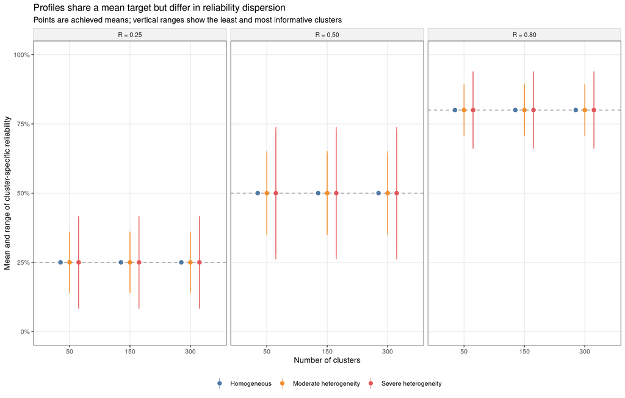

This is the key Study 4 manipulation. The mean target is comparable across profiles, while the severe condition contains clusters with very different posterior uncertainties. The row-specific methods use those differences; the average-measurement variants deliberately discard them.

# 6 Bias

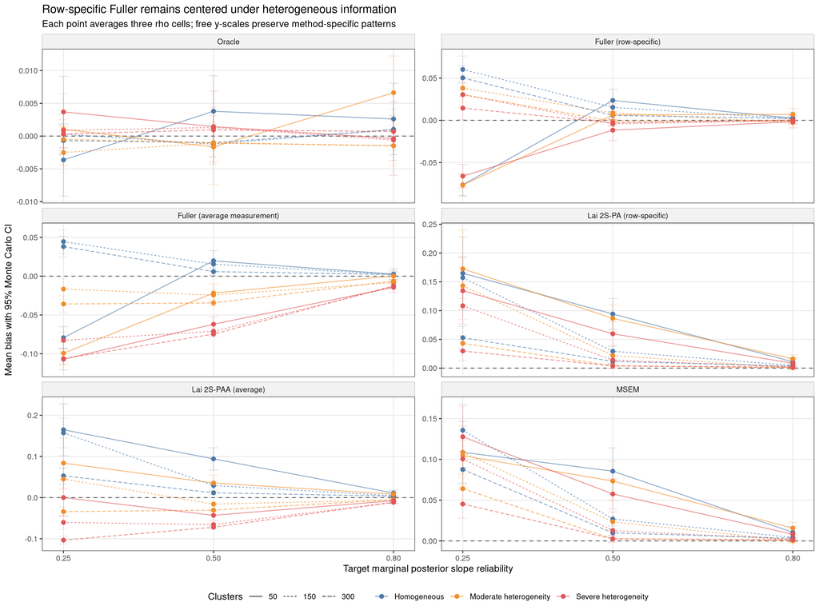

Row-specific Fuller changes little as reliability dispersion increases. Average-measurement Fuller is more negatively biased, consistent with replacing heterogeneous measurement-error matrices by a single average correction. 2S-PA has positive bias, whereas averaging in 2S-PAA shifts the mean bias toward zero but does not uniformly improve interval behavior. MSEM also has modest positive bias in difficult cells.

## 6.1 Negative-control estimators

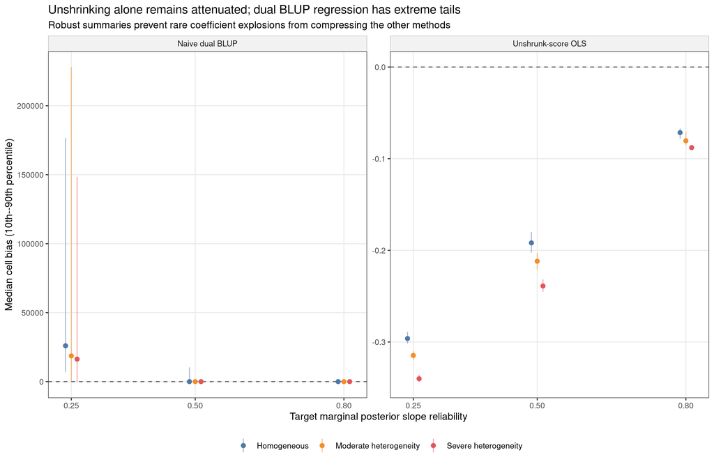

As in Study 2v2, the naive dual-BLUP estimator has rare enormous coefficients from near-collinearity. Those failures remain in the summaries but are not allowed to set a common plot scale. Unshrunk-score OLS shows the expected attenuation because score correction without a Stage-2 measurement-error correction is insufficient for a predictor.

# 7 Coverage and SE calibration

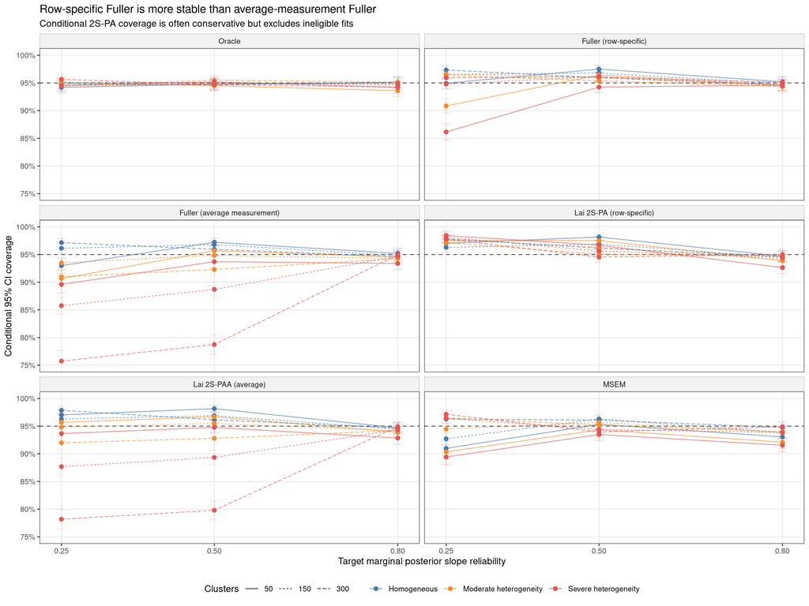

Row-specific Fuller averages 95.1% coverage, compared with 92.5% for average-measurement Fuller. The difference is not merely cosmetic: the average method is also less often eligible. Row-specific 2S-PA has high conditional coverage, but only 88.6% of all non-null replications both yield an eligible interval and cover.

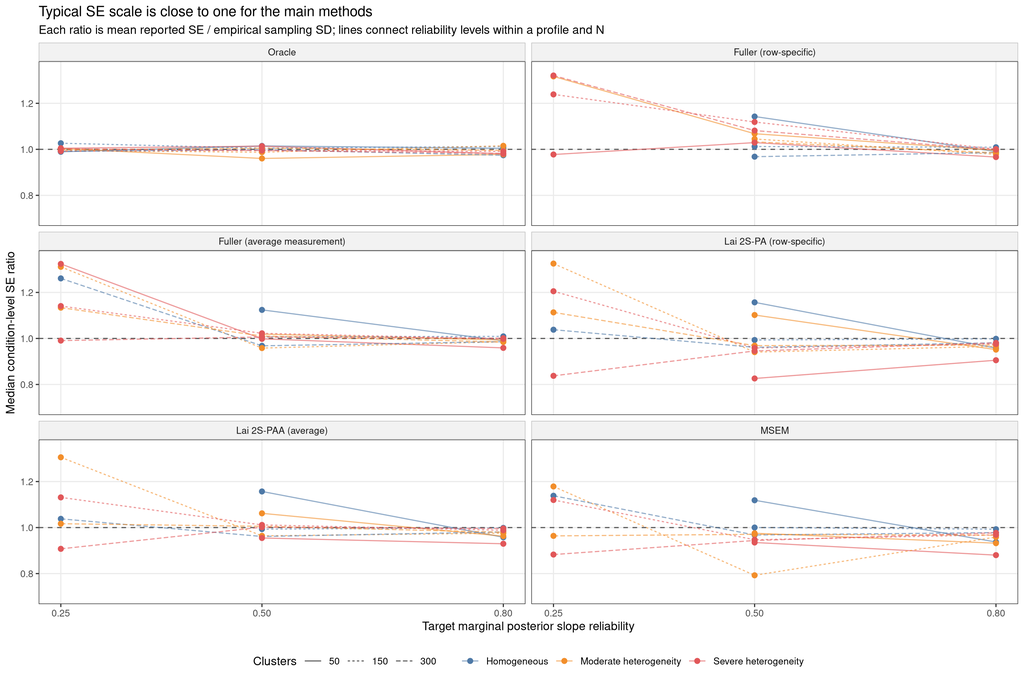

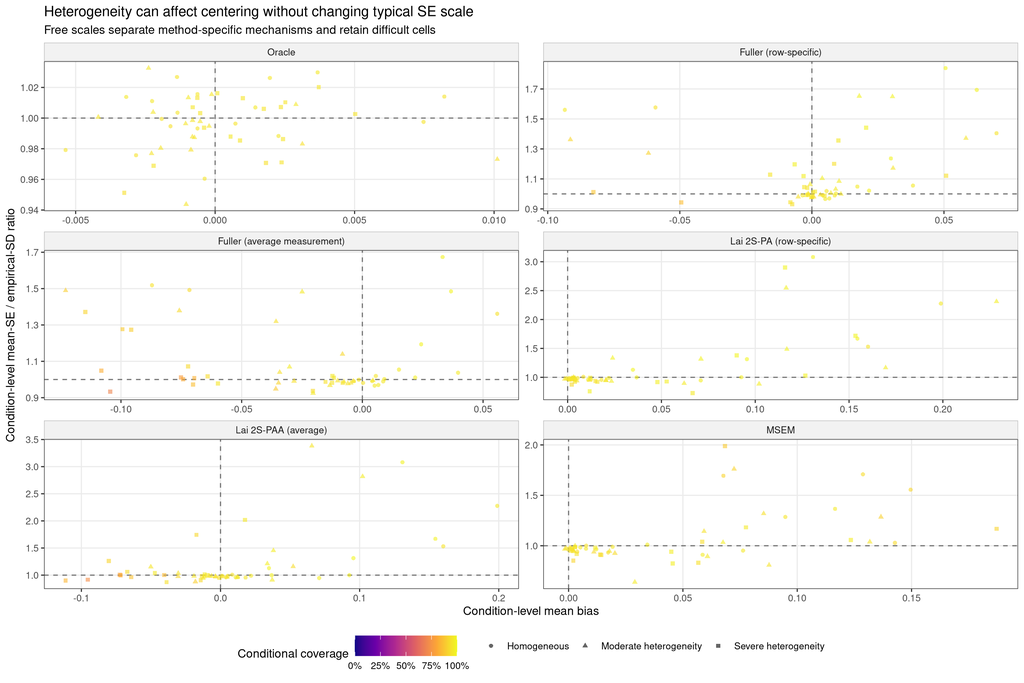

# 8 Row-specific versus average measurement information

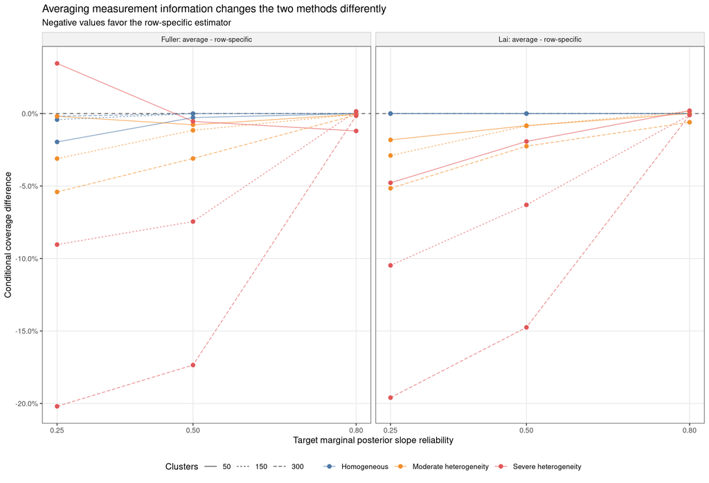

The Fuller comparison gives the cleanest support for the row-specific principle: its average-measurement approximation generally loses coverage and introduces negative bias as heterogeneity grows. Lai’s comparison is not a simple dominance result. Averaging can reduce 2S-PA’s positive bias, but it also changes coverage and does not repair fit eligibility. This distinction should be described as an estimator-specific consequence of averaging, not as a universal theorem that row-specific corrections improve every metric.

# 9 Type I error and operational performance

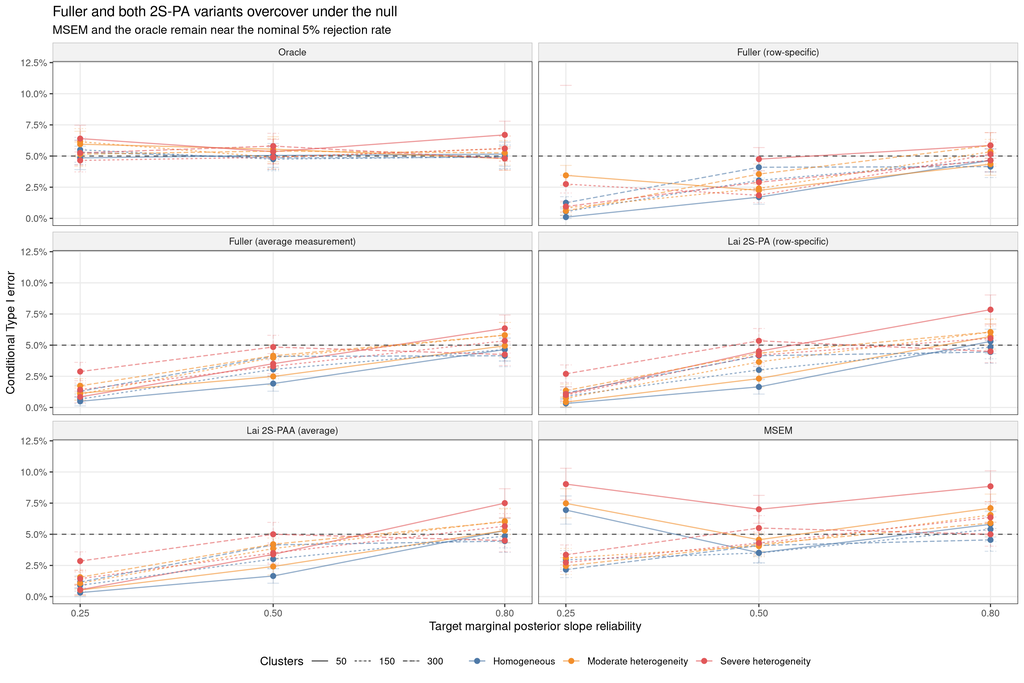

Null rejection makes the overcoverage evidence explicit. Row-specific Fuller, average Fuller, 2S-PA, and 2S-PAA all reject less than 5% on average. MSEM’s average Type I error is 5.1%, compared with 3.5% for row-specific Fuller. Thus, Fuller protects more strongly against false positives, but its coverage advantage partly reflects conservative intervals.

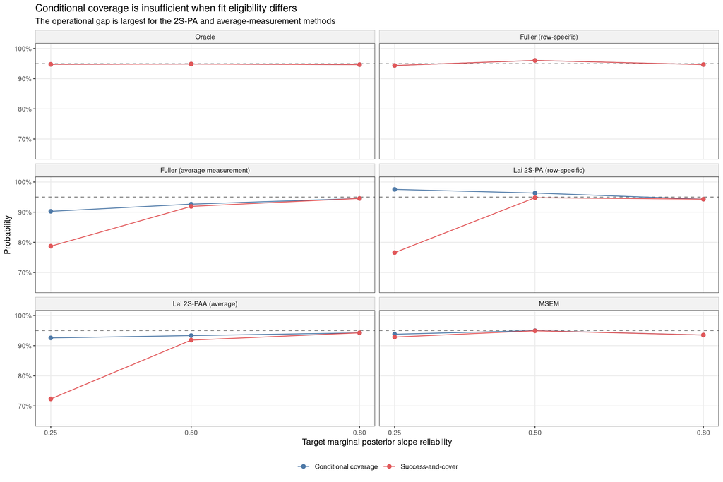

# 10 Direct comparison: row-specific stabilized Fuller, Lai 2S-PA, and MSEM

The primary publication comparison uses the three methods that propagate row-specific information without deliberately averaging it away. Row-specific Fuller corrects the Stage-2 moments using each cluster’s Stage-1 error matrix; Lai 2S-PA represents the cluster-specific scores and uncertainties in an OpenMx latent-variable model; and MSEM estimates the repeated-measures and structural models jointly in Mplus. Because all three methods see the same simulated sample in each condition, matched-cell differences isolate estimator behavior from changes in reliability, information heterogeneity, cluster count, and intercept–slope correlation.

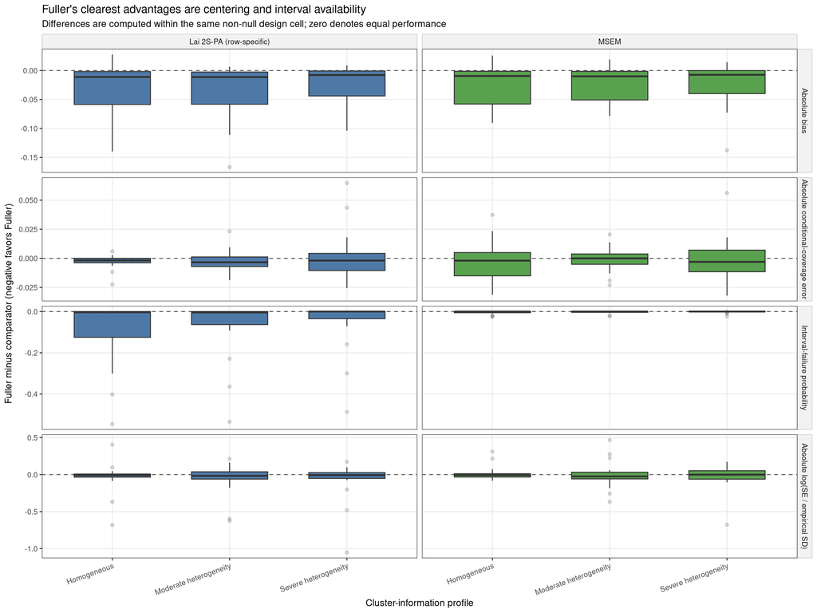

The matched-cell comparison clarifies the tradeoff. Row-specific Fuller has complete interval eligibility in every primary condition and lower absolute bias than the two principal comparators in most cells. Lai 2S-PA often has competitive conditional coverage, but its probability of producing an eligible interval and covering is lower because difficult fits are excluded. MSEM is nearly always available and has null rejection closer to 5%, but its non-null bias and coverage are not uniformly better than Fuller’s.

| Method | Profile | Mean bias | Mean \|bias\| | Conditional coverage | Interval eligible | Success-and-cover | Median condition-level SE ratio | Null Type I error | Operational null rejection |
| --- | --- | --- | --- | --- | --- | --- | --- | --- | --- |
| Fuller (row-specific) | Homogeneous | 0.010 | 0.027 | 96.0% | 100.0% | 96.0% | 1.020 | 2.7% | 2.7% |
| Lai 2S-PA (row-specific) | Homogeneous | 0.059 | 0.059 | 96.2% | 90.6% | 87.1% | 0.993 | 2.9% | 2.8% |
| MSEM | Homogeneous | 0.052 | 0.052 | 94.4% | 99.5% | 93.9% | 0.987 | 4.3% | 4.3% |
| Fuller (row-specific) | Moderate heterogeneity | 0.001 | 0.019 | 95.0% | 100.0% | 95.0% | 1.048 | 3.2% | 3.2% |
| Lai 2S-PA (row-specific) | Moderate heterogeneity | 0.054 | 0.055 | 96.0% | 92.4% | 88.6% | 0.969 | 3.4% | 3.4% |
| MSEM | Moderate heterogeneity | 0.044 | 0.044 | 94.0% | 99.6% | 93.7% | 0.963 | 5.0% | 5.0% |
| Fuller (row-specific) | Severe heterogeneity | -0.005 | 0.015 | 94.2% | 100.0% | 94.2% | 1.028 | 4.6% | 4.6% |
| Lai 2S-PA (row-specific) | Severe heterogeneity | 0.040 | 0.040 | 95.9% | 94.0% | 90.0% | 0.962 | 4.1% | 4.0% |
| MSEM | Severe heterogeneity | 0.040 | 0.040 | 93.9% | 99.8% | 93.7% | 0.967 | 5.8% | 5.8% |

At severe heterogeneity, Fuller’s success-and-cover probability is 94.2%, compared with 90.0% for row-specific Lai 2S-PA and 93.7% for MSEM. This operational contrast is the strongest direct evidence for propagating row-specific uncertainty with a correction that remains available. It does not imply uniform dominance: MSEM provides more nearly nominal null calibration, and the separate average-information analysis below addresses a different question about what is lost by replacing row-specific uncertainty with a common matrix.

# 11 Slope-information controls

The three control conditions retain severe cluster-size imbalance but match slope information. They test whether unequal counts alone produce the row-specific-versus-average differences.

| Number of clusters | Method | Bias | Conditional coverage | Interval eligible | Condition-level mean-SE / empirical-SD ratio |
| --- | --- | --- | --- | --- | --- |
| 50 | Oracle | -0.004 | 94.0% | 100.0% | 0.976 |
| 50 | Fuller (row-specific) | 0.021 | 95.8% | 100.0% | 1.126 |
| 50 | Fuller (average measurement) | 0.016 | 96.1% | 99.1% | 1.080 |
| 50 | Lai 2S-PA (row-specific) | 0.096 | 97.2% | 98.3% | 1.143 |
| 50 | Lai 2S-PAA (average) | 0.080 | 96.6% | 98.8% | 1.087 |
| 50 | MSEM | 0.091 | 95.9% | 100.0% | 1.156 |
| 150 | Oracle | -0.001 | 95.4% | 100.0% | 1.013 |
| 150 | Fuller (row-specific) | 0.013 | 96.3% | 100.0% | 1.012 |
| 150 | Fuller (average measurement) | 0.012 | 95.7% | 100.0% | 0.999 |
| 150 | Lai 2S-PA (row-specific) | 0.026 | 95.9% | 100.0% | 0.995 |
| 150 | Lai 2S-PAA (average) | 0.025 | 95.7% | 100.0% | 0.986 |
| 150 | MSEM | 0.024 | 96.0% | 100.0% | 0.994 |
| 300 | Oracle | 0.000 | 94.4% | 100.0% | 0.981 |
| 300 | Fuller (row-specific) | 0.004 | 95.9% | 100.0% | 1.008 |
| 300 | Fuller (average measurement) | 0.004 | 95.3% | 100.0% | 0.995 |
| 300 | Lai 2S-PA (row-specific) | 0.010 | 95.8% | 100.0% | 0.985 |
| 300 | Lai 2S-PAA (average) | 0.010 | 95.5% | 100.0% | 0.989 |
| 300 | MSEM | 0.007 | 95.8% | 100.0% | 0.989 |

The controls substantially narrow the row-versus-average discrepancy. This supports the intended mechanism: unequal cluster counts matter because they create heterogeneous posterior slope information, not merely because the data set contains small and large clusters.

# 12 Fuller variants

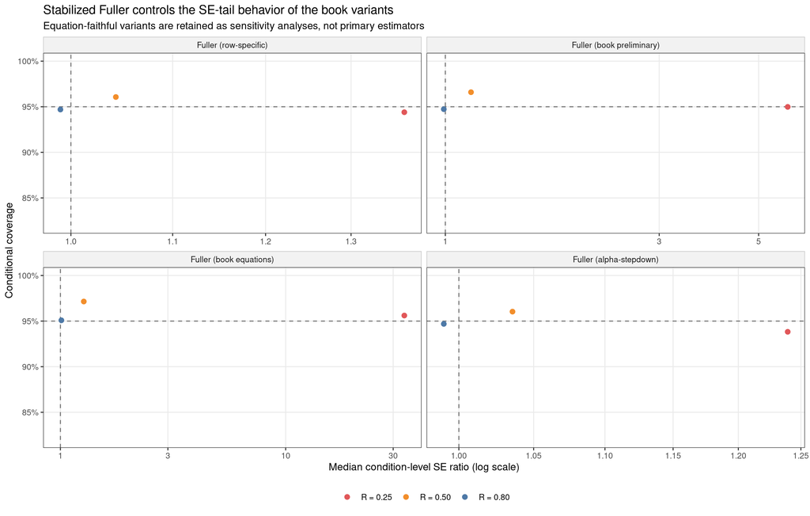

# 13 Conclusions

Study 4v2 supports a coherent message for the VH series. Posterior reliability can be manipulated while preserving latent covariance shape, and cluster-level heterogeneity can then be studied as a separate design feature. This is much easier to explain than changing only the slope variance and hoping that the resulting ICC, reliability, and covariance geometry remain comparable.

The substantive conclusions are balanced:

- Row-specific stabilized Fuller performs well under heterogeneous information. It is nearly unbiased, has complete eligibility, and keeps typical SE scale near the empirical sampling SD. Its null intervals are conservative, so the evidence supports dependable false-positive control rather than exact nominality.
- Averaging Stage-1 error information can be consequential. For Fuller it generally introduces attenuation and lower coverage as heterogeneity grows. This directly supports carrying cluster-specific posterior uncertainty into Stage 2.
- The Lai comparison shows that row-specific information is not guaranteed to improve every metric. 2S-PAA reduces average positive bias but has lower coverage, and both Lai variants lose operational performance through fit ineligibility.
- MSEM remains a valuable benchmark with almost complete eligibility and approximately nominal Type I error. Its modest positive bias and non-null undercoverage in some difficult cells caution against treating it as an infallible reference.
- The slope-information controls show that the operative problem is not unequal cluster size itself. It is heterogeneity in the measurement information attached to the latent slope.

For the paper, Study 4 should therefore be framed as evidence for preserving and propagating the full row-specific uncertainty structure. The primary Fuller estimator should be the corrected, stabilized implementation; the book and alpha-stepdown variants remain informative sensitivity analyses for how regularization changes SE tails.

# 14 Appendix

## 14.1 Compact method summaries

Primary factorial cells only. Cell counts require the condition-level 95% Monte Carlo interval to lie wholly below or above .95.

| Method | Cells | Interval eligible | Mean bias | Mean \|bias\| | Conditional coverage | Success-and-cover | Median condition-level SE ratio | MC interval below .95 | MC interval above .95 |
| --- | --- | --- | --- | --- | --- | --- | --- | --- | --- |
| Unshrunk-score OLS | 54 | 100.0% | -0.203 | 0.203 | 28.3% | 28.3% | 0.985 | 54 | 0 |
| Fuller (alpha-stepdown) | 54 | 100.0% | 0.000 | 0.000 | 94.9% | 94.9% | 1.025 | 9 | 11 |
| Fuller (average measurement) | 54 | 95.5% | -0.027 | 0.027 | 92.5% | 88.4% | 1.005 | 19 | 5 |
| Fuller (book equations) | 54 | 100.0% | 0.003 | 0.003 | 96.0% | 96.0% | 1.270 | 3 | 21 |
| Fuller (book preliminary) | 54 | 100.0% | 0.003 | 0.003 | 95.4% | 95.4% | 1.141 | 5 | 18 |
| Fuller (row-specific) | 54 | 100.0% | 0.002 | 0.002 | 95.1% | 95.1% | 1.027 | 6 | 12 |
| Lai 2S-PA (row-specific) | 54 | 92.3% | 0.051 | 0.051 | 96.1% | 88.6% | 0.977 | 3 | 22 |
| Lai 2S-PAA (average) | 54 | 92.4% | 0.009 | 0.009 | 93.4% | 86.1% | 0.988 | 17 | 9 |
| MSEM | 54 | 99.6% | 0.045 | 0.045 | 94.1% | 93.8% | 0.974 | 18 | 8 |
| Naive dual BLUP | 54 | 95.4% | 23372.982 | 23372.982 | 90.9% | 86.9% | 0.842 | 36 | 0 |
| Oracle | 54 | 100.0% | 0.000 | 0.000 | 94.8% | 94.8% | 0.998 | 3 | 0 |

| Method | Cells | Interval eligible | Mean bias | Conditional Type I error | Operational Type I error | Conditional coverage |
| --- | --- | --- | --- | --- | --- | --- |
| Unshrunk-score OLS | 54 | 100.0% | 0.016 | 8.1% | 8.1% | 91.9% |
| Fuller (alpha-stepdown) | 54 | 100.0% | 0.002 | 3.8% | 3.8% | 96.2% |
| Fuller (average measurement) | 54 | 95.5% | 0.001 | 3.3% | 3.2% | 96.7% |
| Fuller (book equations) | 54 | 100.0% | -0.002 | 3.4% | 3.4% | 96.6% |
| Fuller (book preliminary) | 54 | 100.0% | -0.002 | 3.8% | 3.8% | 96.2% |
| Fuller (row-specific) | 54 | 100.0% | -0.002 | 3.5% | 3.5% | 96.5% |
| Lai 2S-PA (row-specific) | 54 | 92.7% | -0.016 | 3.5% | 3.4% | 96.5% |
| Lai 2S-PAA (average) | 54 | 92.8% | -0.011 | 3.4% | 3.3% | 96.6% |
| MSEM | 54 | 99.5% | -0.019 | 5.1% | 5.0% | 94.9% |
| Naive dual BLUP | 54 | 95.5% | 357.419 | 6.4% | 6.1% | 93.6% |
| Oracle | 54 | 100.0% | 0.000 | 5.3% | 5.3% | 94.7% |

## 14.2 Production artifact provenance

The table describes the recorded environment that generated the condition artifacts, not merely the environment used to render this report.

Distinct production environments recorded for condition IDs 4757–4867 (23 metadata files).

| Pipeline | Git commit | Dirty worktree | Requested replications | R | Mplus | OpenMx | MplusAutomation | lme4 |
| --- | --- | --- | --- | --- | --- | --- | --- | --- |
| openmx_one_row_stage1_covariance_v6_20260817 | a33519fb5f8b45ab570f4eeae7e3a0b742c5b988 | TRUE | 1000 | R version 4.5.1 (2025-06-13) | Mplus VERSION 8.9 (Linux) | 2.22.11 | 1.4 | 2.0.1 |

**Reproducibility note.** The production metadata record a dirty worktree. The commit hashes are therefore base references, not complete snapshots of the source that generated every artifact. The artifact-level v2, method, replication, and design contracts above still protect this report from legacy or structurally incompatible inputs, but a publication freeze should regenerate the final archive from a clean, tagged commit.